# Projet rocket league

2024-11-14

```r
library(tidyverse)
library(dplyr)
library(readr)
```

```r
games_by_players <- read_csv("data/games_by_players.csv")
#https://www.kaggle.com/datasets/dylanmonfret/rlcs-202122
```

## R Markdown

```r
games_by_players_no_NA <- na.omit(games_by_players)
```

```r
games_data <- data.frame(
games_by_players_no_NA %>%
  select(game_id, player_tag, team_id, color, team_region, core_shots, core_goals, core_saves, core_assists, core_score,
         boost_avg_amount, boost_amount_collected, movement_time_boost_speed, movement_time_supersonic_speed,
         movement_time_boost_speed, movement_avg_speed,positioning_avg_distance_to_mates, positioning_time_closest_to_ball,
         positioning_time_offensive_third, positioning_time_offensive_half, positioning_time_defensive_third,
         positioning_time_defensive_half, demo_inflicted,
         advanced_mvp, winner))
```

Question 1) Quels joueurs ont été les plus performants en termes de buts marqués, assistés ou sauvés dans la saison?

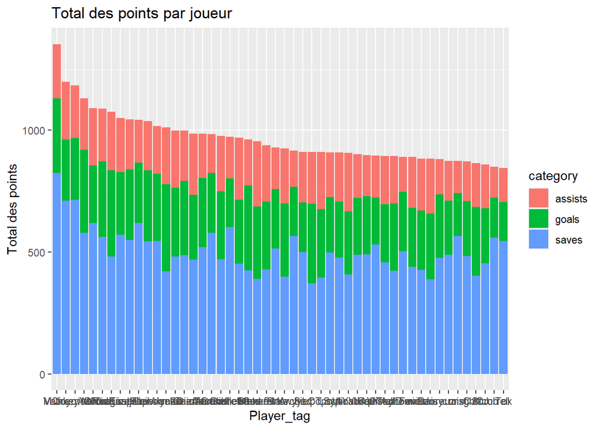

```r
total_points<-games_data %>%
  group_by(player_tag) %>%
  summarize(total_points = sum(core_goals, core_saves, core_assists)) %>%
  arrange(desc(total_points)) %>%
  slice(1:50)

total_points_long <- games_data %>%
  group_by(player_tag) %>%
  summarize(goals = sum(core_goals),
            saves = sum(core_saves),
            assists = sum(core_assists)) %>%
  filter(player_tag %in% total_points$player_tag) %>%
  pivot_longer(cols = c(goals, saves, assists),
               names_to = "category",
               values_to = "points")
ggplot(total_points_long, aes(x = reorder(player_tag, desc(points)), y = points, fill = category)) +
  geom_bar(stat = "identity") +
  labs(title = "Total des points par joueur", x = "Player_tag", y = "Total des points")
```

```r
total_points
```

```
## # A tibble: 50 × 2
##    player_tag  total_points
##    <chr>              <dbl>
##  1 Vatira              1353
##  2 Joyo                1199
##  3 M0nkey M00n         1184
##  4 rise.               1131
##  5 Atomic              1091
##  6 Chicago             1089
##  7 ReaLize             1075
##  8 JKnaps              1050
##  9 Firstkiller         1044
## 10 jstn.               1042
## # ℹ 40 more rows
```

```r
#https://stackoverflow.com/questions/38831020/r-add-lines-or-segments-to-barchart
#https://stt4230.rbind.io/communication_resultats/graphiques_r/#procédure-de-création-dun-graphique
```

```r
total_goal<-games_data %>%
  group_by(player_tag) %>%
  summarise(tot_goal = sum(core_goals, na.rm = TRUE)) %>%
  arrange(desc(tot_goal)) %>%
  slice(1:50)
total_goal
```

```
## # A tibble: 50 × 2
##    player_tag tot_goal
##    <chr>         <dbl>
##  1 Ahmad           359
##  2 ReaLize         354
##  3 Burn            348
##  4 rise.           341
##  5 LCT             327
##  6 Chicago         309
##  7 2Die4           306
##  8 Vatira          306
##  9 Snowyy          300
## 10 Maxeew          296
## # ℹ 40 more rows
```

```r
total_save<-games_data %>%
  group_by(player_tag) %>%
  summarise(tot_save = sum(core_saves, na.rm = TRUE)) %>%
  arrange(desc(tot_save)) %>%
  slice(1:50)
total_save
```

```
## # A tibble: 50 × 2
##    player_tag  tot_save
##    <chr>          <dbl>
##  1 Vatira           824
##  2 M0nkey M00n      714
##  3 Joyo             711
##  4 Atomic           619
##  5 jstn.            618
##  6 GarrettG         602
##  7 AtomiK           578
##  8 rise.            578
##  9 JKnaps           571
## 10 Archie           566
## # ℹ 40 more rows
```

```r
total_assist<-games_data %>%
  group_by(player_tag) %>%
  summarise(tot_assist = sum(core_assists, na.rm = TRUE)) %>%
  arrange(desc(tot_assist)) %>%
  slice(1:50)
total_assist
```

```
## # A tibble: 50 × 2
##    player_tag tot_assist
##    <chr>           <dbl>
##  1 Maxeew            268
##  2 ballerrees        256
##  3 CaioTG1           251
##  4 Lunatic           240
##  5 ReaLize           239
##  6 Joyo              238
##  7 Atomic            235
##  8 popo              235
##  9 yanxnz            235
## 10 Ahmad             233
## # ℹ 40 more rows
```

# https://stackoverflow.com/questions/15291613/merge-3-data-frames-by-column-names

# https://r-graph-gallery.com/218-basic-barplots-with-ggplot2.html

Question 2) Quelles équipes ont remporté le plus de matchs durant la saison régulière de la RCLCS 2021-2022?

Réponse: Les équipes n’ont pas de noms pour les identifier. Elles sont identifiables par leurs numéros d’identification. Ainsi, les trois équipes ayant remporté le plus de math lors de la saison de la RCLCS 2021-2022 sont les équipes 6020bc70f1e4807cc70023a5, 60bbc8518029840609c3b437 et 6065dbab45122f213019c81f avec respectivement 246, 231 et 213 matchs gagnés.

```r
games_data %>%
  group_by(team_id) %>%
  filter(winner == "TRUE")%>%
  distinct(game_id, .keep_all = TRUE) %>%
  count(winner)%>%
  arrange(desc(n)) %>%
  rename("nb.victoires" = n) %>%
  select(team_id, nb.victoires)
```

```
## # A tibble: 538 × 2
## # Groups:   team_id [538]
##    team_id                  nb.victoires
##    <chr>                           <int>
##  1 6020bc70f1e4807cc70023a5          246
##  2 60bbc8518029840609c3b437          231
##  3 6065dbab45122f213019c81f          213
##  4 60b63cfdfec4a0857e7ba00c          203
##  5 6020bc70f1e4807cc7002389          202
##  6 6020bd98f1e4807cc700dc74          202
##  7 6020bc70f1e4807cc70023a0          194
##  8 6020bc70f1e4807cc70023fb          193
##  9 60bb483e6d9c1362119ca7cd          185
## 10 605aca6853a71a78eacbc155          176
## # ℹ 528 more rows
```

```r
#https://www.datanovia.com/en/lessons/identify-and-remove-duplicate-data-in-r/
```

Question 3) Quel a été le plus grand écart de points dans un seul match des séries?

Réponse: Le plus grand écart de point observé lors de la série a été lors de la partie à l’identifiant 61f90c5cda9d7ca1c7ba73c3. Lors de ce match, l’équipe bleue a dominé l’équipe orange avec un différentiel final de +18 points. Pour parvenir à cette conclusion, nous avons généré un graphique à barres, permettant d’illustrer la différence de point entre chaque équipe pour les 50 parties ayant un score final différentiel le plus élevé. Avec ce graphique, nous observons également que les équipes bleues ont tendance à gagner tandis que les équipes orange ont tendance à perdre.

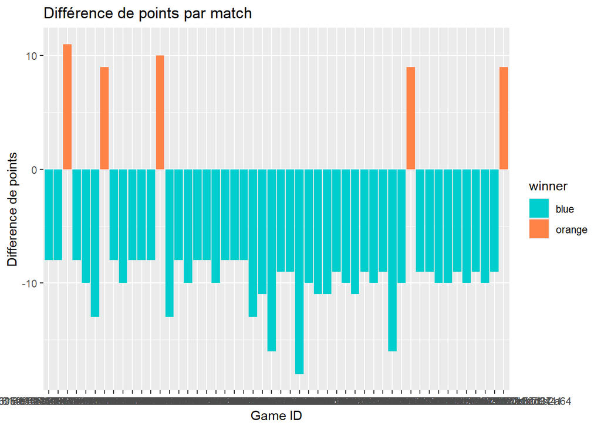

```r
diff_score <- games_data %>%
  group_by(game_id, color) %>%
  summarise(core_score_team = sum(core_goals), .groups = "drop") %>%
  spread(color, core_score_team) %>%
  mutate(
    diff_core_score_team = orange - blue,
    winner = ifelse(diff_core_score_team > 0, "orange", "blue")
  ) %>%
  arrange(desc(abs(diff_core_score_team))) %>%
  slice(1:50)

ggplot(diff_score, aes(x = as.factor(game_id), y = diff_core_score_team, fill = winner)) +
  geom_bar(stat = "identity") +
  labs(title = "Différence de points par match",
       x = "Game ID",
       y = "Difference de points")+
scale_fill_manual(values = c("blue" = "cyan3", "orange" = "#FF8247"))
```

```r
diff_score
```

```
## # A tibble: 50 × 5
##    game_id                   blue orange diff_core_score_team winner
##    <chr>                    <dbl>  <dbl>                <dbl> <chr>
##  1 61f90c5cda9d7ca1c7ba73c3    18      0                  -18 blue
##  2 61e5663ada9d7ca1c7ba5017    16      0                  -16 blue
##  3 627a3c3ec437fde7e02d5ea3    16      0                  -16 blue
##  4 61731962f8090ec745288a9c    14      1                  -13 blue
##  5 6193caf3143c37878b23db00    15      2                  -13 blue
##  6 61e54cfcda9d7ca1c7ba4e54    13      0                  -13 blue
##  7 616d962c143c37878b239c21     0     11                   11 orange
##  8 61e54e6eda9d7ca1c7ba4e88    11      0                  -11 blue
##  9 61f91275da9d7ca1c7ba7521    12      1                  -11 blue
## 10 620a83ffda9d7ca1c7ba8584    12      1                  -11 blue
## # ℹ 40 more rows
```

```r
#https://stackoverflow.com/questions/66755672/how-to-do-subtraction-multiple-column-by-group-in-r
#https://timbolle.github.io/PRO1036/slides/02%20-%20Dataviz/02%20-%20dataviz.html#colour
#https://stackoverflow.com/questions/36048033/manually-colouring-plots-with-scale-fill-manual-in-ggplot2-not-working
#https://r-charts.com/colors/
#https://rfortherestofus.com/2023/10/ggplot-order
```

Question 4) Comment les statistiques de boost influencent la capacité des joueurs à garder une vitesse élevée?

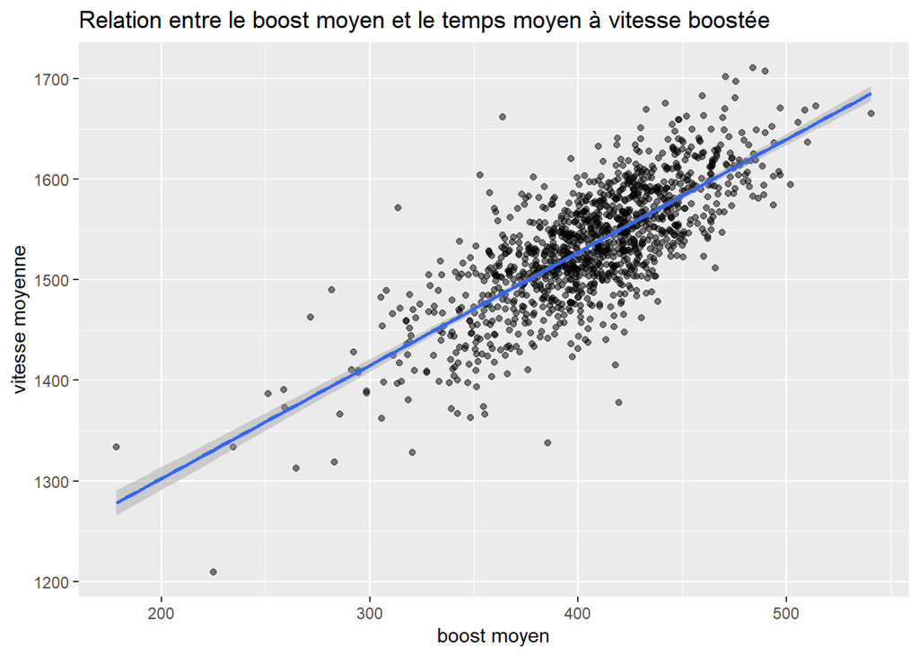

```r
stats_vitesse<-games_by_players %>%
  group_by(player_tag) %>%
  summarize(avg_boost = mean(boost_bcpm, na.rm = TRUE),
            avg_speed= mean(movement_avg_speed, na.rm = TRUE)) %>%
  arrange(desc(avg_speed))

ggplot(stats_vitesse, aes(x = avg_boost, y = avg_speed))+
  geom_point(alpha = 0.5)+
  geom_smooth(method = lm)+
  labs(title = "Relation entre le boost moyen et le temps moyen à vitesse boostée",
       x= "boost moyen",
       y= "vitesse moyenne")
```

Question 5) Quelle est la relation entre la position d’un joueur et son efficacité défensive/offensive?

Réponse: Nous avons fait deux régressions linéaires afin de modéliser en premier lieu la corrélation entre les temps positionnés en défense et le nombre de buts sauvé. Ce graphique permet de remarquer qu’il semble bien exister un lien fort entre ces deux variables. En effet, plus un joueur passe de temps dans le tiers de zone défensif, plus il a d’occasions de bloquer des tirs au but puisqu’il en est proche. En second lieu, nous visualisons la corrélation entre les temps positionnés en offense et le nombre de tirs au but. Nous en déduisons un constat similaire à la corrélation précédente.

En comparant les deux graphiques, nous pouvons voir que ceux concentrés sur la défense passent plus de temps dans leurs tiers de zone respectif pour moins d’interaction avec la balle que ceux en offense. Cela peut s’expliquer par le fait que ceux en défense ont théoriquement un rôle moins actif en général puisque le but qu’ils protègent ne bouge pas comparé à la balle.

```r
Impact_pos_def<-games_data %>%
  group_by(player_tag) %>%
  select(core_saves, positioning_time_defensive_third)  %>%
  summarise(saves_tot= sum(core_saves),
            tot_time_defensive_third = sum(positioning_time_defensive_third)) %>%
  arrange(desc(saves_tot))
```

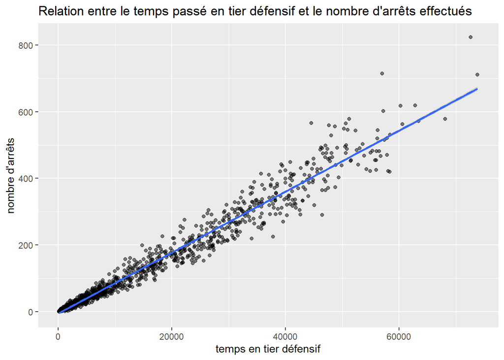

```r
ggplot(Impact_pos_def, aes(x = tot_time_defensive_third, y = saves_tot))+
  geom_point(alpha = 0.5)+
  geom_smooth(method = lm)+
  labs(title = "Relation entre le temps passé en tier défensif et le nombre d'arrêts effectués",
       x= "temps en tier défensif",
       y= "nombre d'arrêts")
```

```r
Impact_pos_def
```

```
## # A tibble: 1,216 × 3
##    player_tag  saves_tot tot_time_defensive_third
##    <chr>           <dbl>                    <dbl>
##  1 Vatira            824                   72579.
##  2 M0nkey M00n       714                   57048.
##  3 Joyo              711                   73789.
##  4 Atomic            619                   62795.
##  5 jstn.             618                   60247.
##  6 GarrettG          602                   57242.
##  7 AtomiK            578                   51194.
##  8 rise.             578                   68103.
##  9 JKnaps            571                   63452.
## 10 Archie            566                   44560.
## # ℹ 1,206 more rows
```

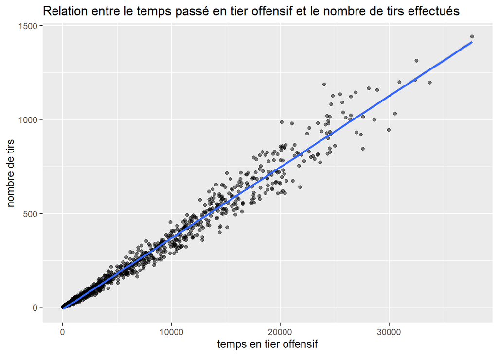

```r
Impact_pos_off<-games_data %>%
  group_by(player_tag) %>%
  select(core_shots, positioning_time_offensive_third, player_tag)  %>%
  summarise(shots_tot= sum(core_shots),
            tot_time_offensive_third = sum(positioning_time_offensive_third)) %>%
  arrange(desc(shots_tot))

ggplot(Impact_pos_off, aes(x = tot_time_offensive_third, y = shots_tot))+
  geom_point(alpha = 0.5)+
  geom_smooth(method = lm)+
  labs(title = "Relation entre le temps passé en tier offensif et le nombre de tirs effectués",
       x= "temps en tier offensif",
       y= "nombre de tirs")
```

```r
Impact_pos_off
```

```
## # A tibble: 1,216 × 3
##    player_tag  shots_tot tot_time_offensive_third
##    <chr>           <dbl>                    <dbl>
##  1 rise.            1441                   37621.
##  2 Vatira           1312                   32534.
##  3 Chicago          1211                   32418.
##  4 Ahmad            1199                   30969.
##  5 Joyo             1197                   33748.
##  6 Burn             1187                   24039.
##  7 JKnaps           1164                   28128.
##  8 ReaLize          1158                   28913.
##  9 Firstkiller      1143                   26942.
## 10 Seikoo           1133                   25493.
## # ℹ 1,206 more rows
```

Hypothèse 1: Les équipes avec un ou des joueurs souvent MVP gagnent plus souvent.

(Ce code peut être un peu lent à charger…)

```r
MVP_players<-games_data %>%
  group_by(player_tag) %>%
  mutate(MVP = sum(advanced_mvp)) %>%
  group_by(team_id, player_tag) %>%
  mutate(
    winning = case_when(
        winner=="TRUE" ~ 1,
        winner=="FALSE" ~ 0)) %>%
  summarise(MVP,
            wins = sum(winning)) %>%
  distinct(player_tag, .keep_all = TRUE) %>%
  arrange(desc(MVP))
```

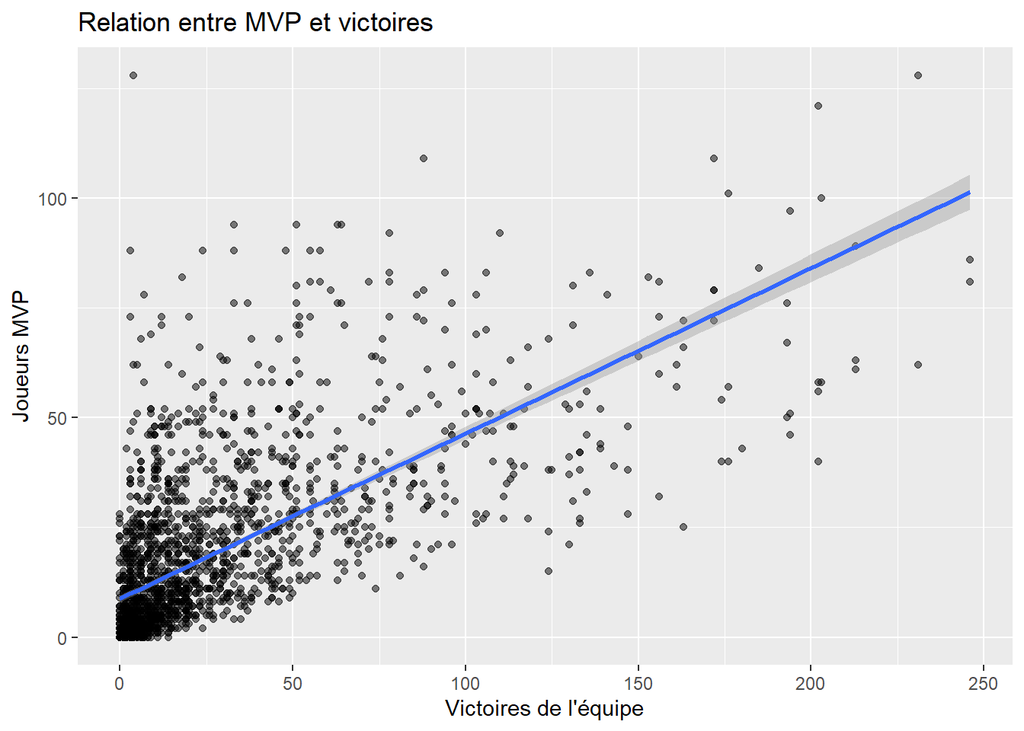

```r
ggplot(MVP_players, aes(x = wins, y = MVP)) +
  geom_point(alpha = 0.5) +
  geom_smooth(method = lm)+
  labs(x = "Victoires de l'équipe", y = "Joueurs MVP", title = "Relation entre MVP et victoires")
```

```r
#https://www.datanovia.com/en/blog/how-to-remove-legend-from-a-ggplot/
```

Hypothèse 2: les équipes qui maintiennent un temps de possession de balle élevée et un bon taux de tirs cadrés ont plus de chance de remporter leurs matchs.

Réponse: En mettant en relation le temps total où les équipes étaient en possession de la balle avec le nombre de victoires de celle-ci, nous pouvons voir une tendance linéaire claire. Nous pouvons donc considérer qu’une équipe réussissant à garder la balle pendant de longues périodes de temps a une meilleure chance de remporter la victoire. Nous pouvons également constater que l’équipe avec le temps de possession le plus élevé est également celle avec le plus grand nombre de victoires. Alors que pour la précision des tirs au but, nous pouvons tout de suite constater que la relation n’est pas croissante linéaire. Effectivement, les équipes avec une précision un peu plus bas que la moyenne sont celles avec le plus de victoires. La moyenne semblant être aux alentours de 27%, la précision ne semble vraiment pas être un facteur déterminant de victoires. Pour mieux expliquer ce phénomène, la couleur du graphique est un dégradé représentant le nombre de tirs au but des équipes. On peut donc observer que celui-ci semble être élevé pour les équipe gagnante et basse pour celles perdantes. Évidemment, si tu ne réussis qu’à tenter 5 buts et en réussis 4, ta précision est de 80%, mais tu n’as quand même fait que 4 buts. Tandis qu’une équipe ayant tenté 3000 tirs au but avec une précision de 25% ressortira avec 750 buts.

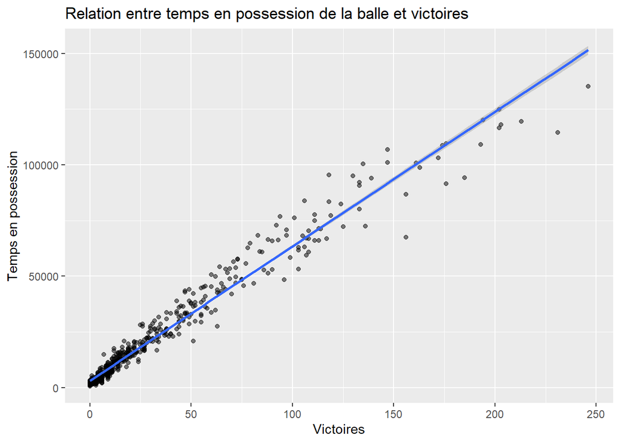

```r
time_ball<-games_data %>%
  group_by(team_id) %>%
  mutate(
    winning = case_when(
        winner=="TRUE" ~ 1,
        winner=="FALSE" ~ 0)) %>%
  summarise(time_ball_team = sum(positioning_time_closest_to_ball),
            wins = sum(winning)/3) %>%
  arrange(desc(time_ball_team))

ggplot(time_ball, aes(x = wins, y = time_ball_team)) +
  geom_point(alpha = 0.5) +
  geom_smooth(method = lm)+
  labs(x = "Victoires", y = "Temps en possession", title = "Relation entre temps en possession de la balle et victoires")
```

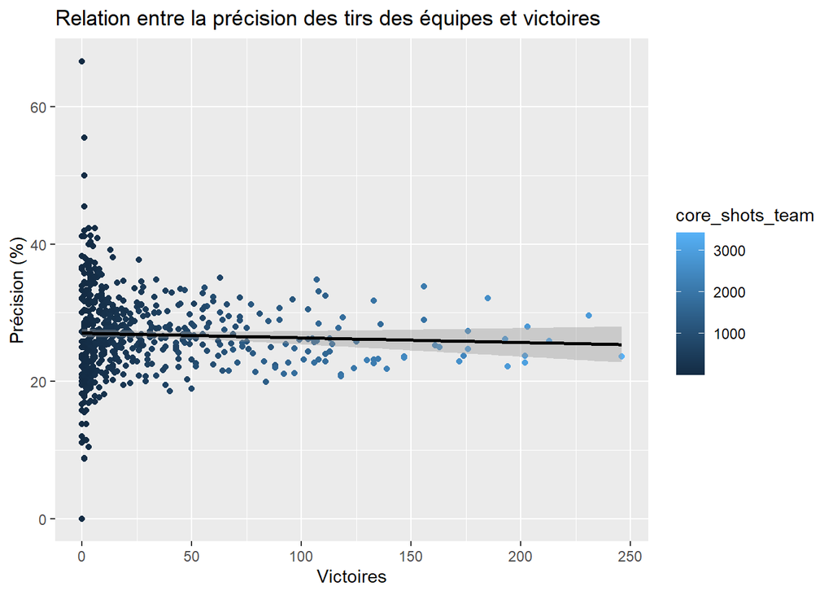

```r
precision_rate<-games_data %>%
  group_by(team_id) %>%
  mutate(
    winning = case_when(
        winner=="TRUE" ~ 1,
        winner=="FALSE" ~ 0)) %>%
  summarise(core_shots_team = sum(core_shots),
            core_goals_team = sum(core_goals),
            rate_precision_team = (core_goals_team/core_shots_team*100),
            wins = sum(winning)/3) %>%
  arrange(desc(rate_precision_team))

ggplot(precision_rate, aes(x = wins, y = rate_precision_team, colour = core_shots_team)) +
  geom_point() +
  geom_smooth(method = lm, colour = "black")+
  labs(x = "Victoires", y = "Précision (%)", title = "Relation entre la précision des tirs des équipes et victoires")
```

Hypothèse 3 : les équipes qui adoptent un style de jeu plus offensif on plus de succès, puisqu’elles réduisent le nombre de défenseurs et se concentrent sur l’attaque.

Réponse: Quatre variables ont été regroupées en un graphique: le temps dans la moitié offensive, le temps dans le tiers offensif, le nombre de démolitions et le nombre de victoires. Puisque le tiers de zone est inclus dans la moitié de zone, elle est représentée par un dégradé de couleur. La quantité de démolitions est représentée par la grosseur des points. Si l’on regarde ces trois indicateurs séparément, l’on peut voir que leurs valeurs semblent augmenter avec le nombre de victoires. De plus, si l’on analyse ces trois variables ensemble, on peut voir qu’elles semblent avoir une tendance commune: les équipes ayant les plus grandes valeurs dans les trois catégories sont aussi celles gagnantes. Si l’on devait choisir, la valeur ayant l’impact le moins important est vraisemblablement le nombre de démolitions, puisque sa croissance est la moins constante. Donc d’adopter un mode de jeu agressif est à première vue avantageux et favorise les victoires.

```r
demolition<-games_data %>%
  group_by(team_id) %>%
  mutate(
    winning = case_when(
        winner=="TRUE" ~ 1,
        winner=="FALSE" ~ 0)) %>%
  summarise(demo_inflicted_team = sum(demo_inflicted),
            wins = sum(winning)/3) %>%
  arrange(desc(demo_inflicted_team))
```

```r
time_third<-games_data %>%
  group_by(team_id) %>%
  mutate(
    winning = case_when(
        winner=="TRUE" ~ 1,
        winner=="FALSE" ~ 0)) %>%
  summarise(time_offensive_third_team = sum(positioning_time_offensive_third),
            time_defensive_third_team = sum(positioning_time_defensive_third),
            wins = sum(winning)/3) %>%
  arrange(desc(time_offensive_third_team))
```

```r
time_half<-games_data %>%
  group_by(team_id) %>%
  mutate(
    winning = case_when(
        winner=="TRUE" ~ 1,
        winner=="FALSE" ~ 0)) %>%
  summarise(time_offensive_half_team = sum(positioning_time_offensive_half),
            time_defensive_half_team = sum(positioning_time_defensive_half),
            wins = sum(winning)/3) %>%
  arrange(desc(time_offensive_half_team))
```

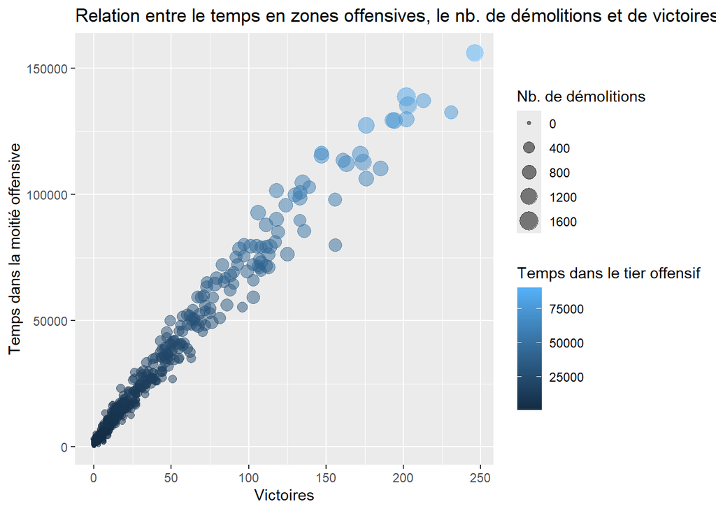

```r
offensive<- merge(demolition, time_half) %>% merge(time_third)


ggplot(offensive, aes(x = wins, y = time_offensive_half_team, colour = time_offensive_third_team, size = demo_inflicted_team)) +
  geom_point(alpha = 0.5)+
  labs(x = "Victoires", y = "Temps dans la moitié offensive", title = "Relation entre le temps en zones offensives, le nb. de démolitions et de victoires", colour = "Temps dans le tier offensif", size = "Nb. de démolitions")
```

```r
#https://stackoverflow.com/questions/15291613/merge-3-data-frames-by-column-names
```